# Ford GoBike Data Exploration

## Preliminary Wrangling

> This document explores the Ford GoBike dataset. Ford GoBike is a bike sharing system in the Bay Area, USA. People can become an annual member or buy a single ride or access pass to use public bikes available at any Ford GoBike station. With an annual membership a member (or a 'subscriber') can use a bike for unlimited 45 minute-trips, while a causal user (a.k.a 'customer') can enjoy one ride up to 30 minutes ('Single Ride') or unlimited 30-minute-trip in a 24 hour period ('Access Pass'). The following documents contain Ford GoBike's trip data until April 2019.

```python
# import all packages and set plots to be embedded inline
import numpy as np
import pandas as pd
import matplotlib.pyplot as plt
import seaborn as sb

%matplotlib inline
```

```python
# load in the dataset into a pandas dataframe, print statistics
bike = pd.read_csv('201904-fordgobike-tripdata.csv')
```

```python
# high-level overview of data shape and composition
print(bike.shape)
print(bike.dtypes)
bike.head(10)
```

```
(239111, 16)
duration_sec                 int64
start_time                  object
end_time                    object
start_station_id           float64
start_station_name          object
start_station_latitude     float64
start_station_longitude    float64
end_station_id             float64
end_station_name            object
end_station_latitude       float64
end_station_longitude      float64
bike_id                      int64
user_type                   object
member_birth_year          float64
member_gender               object
bike_share_for_all_trip     object
dtype: object
```

|  | duration_sec | start_time | end_time | start_station_id | start_station_name | start_station_latitude | start_station_longitude | end_station_id | end_station_name | end_station_latitude | end_station_longitude | bike_id | user_type | member_birth_year | member_gender | bike_share_for_all_trip |
| --- | --- | --- | --- | --- | --- | --- | --- | --- | --- | --- | --- | --- | --- | --- | --- | --- |
| 0 | 50305 | 2019-04-30 22:33:55.1550 | 2019-05-01 12:32:20.4540 | 368.0 | Myrtle St at Polk St | 37.785434 | -122.419622 | 324.0 | Union Square (Powell St at Post St) | 37.788300 | -122.408531 | 2749 | Subscriber | 1989.0 | Female | No |
| 1 | 53725 | 2019-04-30 20:43:41.6320 | 2019-05-01 11:39:06.9170 | 246.0 | Berkeley Civic Center | 37.869060 | -122.270556 | 241.0 | Ashby BART Station | 37.852477 | -122.270213 | 2608 | Customer | NaN | NaN | No |
| 2 | 78072 | 2019-04-30 10:32:46.4890 | 2019-05-01 08:13:58.9750 | 64.0 | 5th St at Brannan St | 37.776754 | -122.399018 | 64.0 | 5th St at Brannan St | 37.776754 | -122.399018 | 258 | Subscriber | 1993.0 | Male | No |
| 3 | 78969 | 2019-04-30 10:00:51.5500 | 2019-05-01 07:57:01.2620 | 67.0 | San Francisco Caltrain Station 2 (Townsend St... | 37.776639 | -122.395526 | 89.0 | Division St at Potrero Ave | 37.769218 | -122.407646 | 1974 | Subscriber | 1972.0 | Male | No |
| 4 | 1128 | 2019-04-30 23:59:04.7390 | 2019-05-01 00:17:53.0910 | 124.0 | 19th St at Florida St | 37.760447 | -122.410807 | 5.0 | Powell St BART Station (Market St at 5th St) | 37.783899 | -122.408445 | 877 | Subscriber | 1973.0 | Male | No |
| 5 | 1388 | 2019-04-30 23:53:05.9820 | 2019-05-01 00:16:14.3130 | 243.0 | Bancroft Way at College Ave | 37.869360 | -122.254337 | 247.0 | Fulton St at Bancroft Way | 37.867789 | -122.265896 | 3234 | Customer | 1997.0 | Male | No |
| 6 | 920 | 2019-04-30 23:57:56.3400 | 2019-05-01 00:13:16.4540 | 202.0 | Washington St at 8th St | 37.800754 | -122.274894 | 220.0 | San Pablo Ave at MLK Jr Way | 37.811351 | -122.273422 | 3262 | Subscriber | 1976.0 | Male | Yes |
| 7 | 725 | 2019-04-30 23:56:11.2190 | 2019-05-01 00:08:16.9150 | 44.0 | Civic Center/UN Plaza BART Station (Market St ... | 37.781074 | -122.411738 | 121.0 | Mission Playground | 37.759210 | -122.421339 | 2706 | Customer | 1973.0 | Male | No |
| 8 | 488 | 2019-04-30 23:59:00.6600 | 2019-05-01 00:07:08.9750 | 21.0 | Montgomery St BART Station (Market St at 2nd St) | 37.789625 | -122.400811 | 64.0 | 5th St at Brannan St | 37.776754 | -122.399018 | 860 | Subscriber | 1986.0 | Male | No |
| 9 | 792 | 2019-04-30 23:53:37.6040 | 2019-05-01 00:06:50.4050 | 28.0 | The Embarcadero at Bryant St | 37.787168 | -122.388098 | 126.0 | Esprit Park | 37.761634 | -122.390648 | 896 | Subscriber | 1995.0 | Male | No |

```python
bike.describe()
```

|  | duration_sec | start_station_id | start_station_latitude | start_station_longitude | end_station_id | end_station_latitude | end_station_longitude | bike_id | member_birth_year |
| --- | --- | --- | --- | --- | --- | --- | --- | --- | --- |
| count | 239111.000000 | 239047.000000 | 239111.000000 | 239111.000000 | 239047.000000 | 239111.000000 | 239111.000000 | 239111.000000 | 227912.000000 |
| mean | 802.671199 | 141.836538 | 37.769536 | -122.352503 | 140.838099 | 37.766996 | -122.343420 | 3666.956493 | 1984.863250 |
| std | 1990.006091 | 116.289776 | 0.127698 | 0.277088 | 116.386168 | 0.343083 | 1.068144 | 2180.717333 | 9.953144 |
| min | 61.000000 | 3.000000 | 0.000000 | -122.453704 | 3.000000 | 0.000000 | -122.453704 | 11.000000 | 1878.000000 |
| 25% | 349.000000 | 47.000000 | 37.770083 | -122.413004 | 44.000000 | 37.770407 | -122.411738 | 1720.000000 | 1980.000000 |
| 50% | 558.000000 | 104.000000 | 37.780760 | -122.398285 | 102.000000 | 37.780955 | -122.397437 | 3471.000000 | 1987.000000 |
| 75% | 876.000000 | 240.000000 | 37.797280 | -122.291209 | 239.000000 | 37.797320 | -122.291376 | 5749.000000 | 1992.000000 |
| max | 86114.000000 | 420.000000 | 37.880222 | 0.000000 | 420.000000 | 37.880222 | 0.000000 | 7108.000000 | 2001.000000 |

### What is the structure of your dataset?

> There are 239,111 trip data with 16 features (trip duration in sec, start time and date, end time and date, start station ID, start station name, start station latitude, start station longitude, end station id, end station name, end station latitude, end station longitude, bike ID, user type, member year of birth, member gender, bike share for all trip). Most variables are categorical in nature, and although some variables numeric, probably one most meaningul numeric variable would be trip duraiton.

### What is/are the main feature(s) of interest in your dataset?

> I am interested in finding out who are the main users of the GoBike system and how the features of users influence their trip duration.

### What features in the dataset do you think will help support your investigation into your feature(s) of interest?

> In order to identify main users, variables such as user type, member year of birth, member gender can be useful. For example, those variables can show whether the system is largely used by local residents or visitors ('user type'), by what age group ('member year of birth'), and by male or female ('member gender'). However, considering the fact that a bike can be used by a various age group, it might be more interesting to investigate user type and gender only. By identifying those features of users, I am planning to investigate if these features influence their trip duration. It would also be useful if there is any data available that can show the travelling distance to explore their travelling pattern, but unfortunately this data is not available on the dataset. However, by looking at the start and end point, we can add a new variable that can show their travelling pattern, such as whether a bike is used for a return journey (i.e. the start point is same as the end point: in this case, perhaps more custmers use the system for touring?) or for short transportation (i.e. the start point is different from the end point: in this case, perhpas more subscribers use the system to commute?). Therefore, we can add this variable to the dataset for further investigation.

### Data cleaning and exploration

```python
# create a new variable that shows whether the start point = end point 'return journey'
bike['return_j'] = (bike['start_station_id']==bike['end_station_id']).astype(int)
```

```python
bike['return_j'].replace(0, 'No Return', inplace=True)
bike['return_j'].replace(1, 'Return', inplace=True)
```

```python
# check if the variable is successfully created and added to the dataset
bike.head()
```

|  | duration_sec | start_time | end_time | start_station_id | start_station_name | start_station_latitude | start_station_longitude | end_station_id | end_station_name | end_station_latitude | end_station_longitude | bike_id | user_type | member_birth_year | member_gender | bike_share_for_all_trip | return_j |
| --- | --- | --- | --- | --- | --- | --- | --- | --- | --- | --- | --- | --- | --- | --- | --- | --- | --- |
| 0 | 50305 | 2019-04-30 22:33:55.1550 | 2019-05-01 12:32:20.4540 | 368.0 | Myrtle St at Polk St | 37.785434 | -122.419622 | 324.0 | Union Square (Powell St at Post St) | 37.788300 | -122.408531 | 2749 | Subscriber | 1989.0 | Female | No | No Return |
| 1 | 53725 | 2019-04-30 20:43:41.6320 | 2019-05-01 11:39:06.9170 | 246.0 | Berkeley Civic Center | 37.869060 | -122.270556 | 241.0 | Ashby BART Station | 37.852477 | -122.270213 | 2608 | Customer | NaN | NaN | No | No Return |
| 2 | 78072 | 2019-04-30 10:32:46.4890 | 2019-05-01 08:13:58.9750 | 64.0 | 5th St at Brannan St | 37.776754 | -122.399018 | 64.0 | 5th St at Brannan St | 37.776754 | -122.399018 | 258 | Subscriber | 1993.0 | Male | No | Return |
| 3 | 78969 | 2019-04-30 10:00:51.5500 | 2019-05-01 07:57:01.2620 | 67.0 | San Francisco Caltrain Station 2 (Townsend St... | 37.776639 | -122.395526 | 89.0 | Division St at Potrero Ave | 37.769218 | -122.407646 | 1974 | Subscriber | 1972.0 | Male | No | No Return |
| 4 | 1128 | 2019-04-30 23:59:04.7390 | 2019-05-01 00:17:53.0910 | 124.0 | 19th St at Florida St | 37.760447 | -122.410807 | 5.0 | Powell St BART Station (Market St at 5th St) | 37.783899 | -122.408445 | 877 | Subscriber | 1973.0 | Male | No | No Return |

```python
# create a sub dataset that contains only variables that we are going to use for exploration
bike_sub = bike[['duration_sec', 'bike_id', 'user_type', 'member_gender', 'return_j']]
```

```python
print(bike_sub.shape)
print(bike_sub.dtypes)
bike_sub.head()
# now there are 23911 rows with 5 columns
```

```
(239111, 5)
duration_sec      int64
bike_id           int64
user_type        object
member_gender    object
return_j         object
dtype: object
```

|  | duration_sec | bike_id | user_type | member_gender | return_j |
| --- | --- | --- | --- | --- | --- |
| 0 | 50305 | 2749 | Subscriber | Female | No Return |
| 1 | 53725 | 2608 | Customer | NaN | No Return |
| 2 | 78072 | 258 | Subscriber | Male | Return |
| 3 | 78969 | 1974 | Subscriber | Male | No Return |
| 4 | 1128 | 877 | Subscriber | Male | No Return |

```python
# to see if there is any entry with no duration
sum(bike_sub.duration_sec.isnull())
```

```
0
```

```python
# to see if there is any entry with no return value
sum(bike_sub.return_j.isna())
```

```
0
```

```python
# to check unique value of user_type
bike_sub.user_type.unique()
```

```
array(['Subscriber', 'Customer'], dtype=object)
```

```python
# to check unique value of member_gender
bike_sub.member_gender.unique()
# the result shows that there are NaN and a category called 'Other'.
```

```
array(['Female', nan, 'Male', 'Other'], dtype=object)
```

```python
# we don't know what 'other' could mean. Therefore, we will drop these rows that contain NaN and Other,
# and create a subset that contains only Male and Female
bike_sub1 = bike_sub.loc[bike_sub['member_gender'].isin(['Male', 'Female'])]
```

```python
# check if they are dropped successfully
bike_sub1.member_gender.unique()
```

```
array(['Female', 'Male'], dtype=object)
```

```python
# However, as the column name 'member_gender' suggests, it might contain only data of 'subscribers'
# let's check if it's true
bike_sub1.query('user_type == "Customer"')
# this shows that the 'member_gender' column actually shows gender of all users including both subscribers and customers
```

|  | duration_sec | bike_id | user_type | member_gender | return_j |
| --- | --- | --- | --- | --- | --- |
| 5 | 1388 | 3234 | Customer | Male | No Return |
| 7 | 725 | 2706 | Customer | Male | No Return |
| 21 | 227 | 629 | Customer | Male | No Return |
| 31 | 397 | 501 | Customer | Male | No Return |
| 41 | 600 | 828 | Customer | Male | No Return |
| 47 | 668 | 1961 | Customer | Female | No Return |
| 88 | 1546 | 3289 | Customer | Male | Return |
| 90 | 1380 | 2634 | Customer | Male | No Return |
| 110 | 832 | 1249 | Customer | Male | No Return |
| 118 | 877 | 3653 | Customer | Female | No Return |
| 120 | 731 | 256 | Customer | Male | No Return |
| 124 | 814 | 3263 | Customer | Female | No Return |
| 129 | 581 | 192 | Customer | Male | No Return |
| 162 | 660 | 2047 | Customer | Male | No Return |
| 165 | 210 | 1549 | Customer | Male | No Return |
| 179 | 377 | 1552 | Customer | Male | No Return |
| 185 | 9193 | 238 | Customer | Male | No Return |
| 196 | 381 | 1149 | Customer | Male | No Return |
| 213 | 493 | 551 | Customer | Female | No Return |
| 216 | 531 | 3015 | Customer | Male | No Return |
| 226 | 796 | 2692 | Customer | Female | No Return |
| 229 | 445 | 2159 | Customer | Male | No Return |
| 231 | 592 | 48 | Customer | Male | No Return |
| 232 | 573 | 3123 | Customer | Male | No Return |
| 236 | 832 | 746 | Customer | Male | No Return |
| 238 | 825 | 3158 | Customer | Male | No Return |
| 244 | 1109 | 1679 | Customer | Male | No Return |
| 245 | 593 | 192 | Customer | Male | No Return |
| 246 | 1078 | 431 | Customer | Female | No Return |
| 247 | 431 | 2864 | Customer | Male | No Return |
| ... | ... | ... | ... | ... | ... |
| 238737 | 659 | 2361 | Customer | Male | No Return |
| 238740 | 1161 | 4738 | Customer | Male | No Return |
| 238770 | 1011 | 6597 | Customer | Male | No Return |
| 238824 | 162 | 3136 | Customer | Male | No Return |
| 238827 | 447 | 4625 | Customer | Male | No Return |
| 238850 | 157 | 3571 | Customer | Male | No Return |
| 238861 | 849 | 6857 | Customer | Female | No Return |
| 238879 | 265 | 274 | Customer | Male | No Return |
| 238909 | 131 | 1586 | Customer | Male | No Return |
| 238911 | 212 | 6682 | Customer | Male | No Return |
| 238921 | 1124 | 1307 | Customer | Male | No Return |
| 238942 | 568 | 5785 | Customer | Male | No Return |
| 238948 | 427 | 6799 | Customer | Male | No Return |
| 238965 | 914 | 2916 | Customer | Male | No Return |
| 238966 | 235 | 4404 | Customer | Male | No Return |
| 238969 | 860 | 6259 | Customer | Female | No Return |
| 239029 | 256 | 5129 | Customer | Female | No Return |
| 239032 | 719 | 6563 | Customer | Male | No Return |
| 239042 | 5740 | 5376 | Customer | Male | Return |
| 239049 | 120 | 6912 | Customer | Male | No Return |
| 239055 | 1820 | 6788 | Customer | Male | Return |
| 239056 | 1755 | 1003 | Customer | Male | Return |
| 239058 | 1724 | 4641 | Customer | Male | Return |
| 239059 | 1754 | 2648 | Customer | Male | Return |
| 239074 | 274 | 6692 | Customer | Male | No Return |
| 239076 | 1318 | 6846 | Customer | Male | No Return |
| 239077 | 2108 | 5970 | Customer | Male | No Return |
| 239089 | 163 | 1850 | Customer | Male | No Return |
| 239091 | 209 | 1850 | Customer | Male | No Return |
| 239103 | 869 | 5910 | Customer | Male | Return |

28716 rows × 5 columns

```python
# to correctly reflect the variable, let's change the column 'member_gender' name to 'user_gender'
bike_sub1.rename(columns={'member_gender': 'user_gender'}, inplace=True)
```

```python
# to check if it's correctly done
bike_sub1.head(5)
```

|  | duration_sec | bike_id | user_type | user_gender | return_j |
| --- | --- | --- | --- | --- | --- |
| 0 | 50305 | 2749 | Subscriber | Female | No Return |
| 2 | 78072 | 258 | Subscriber | Male | Return |
| 3 | 78969 | 1974 | Subscriber | Male | No Return |
| 4 | 1128 | 877 | Subscriber | Male | No Return |
| 5 | 1388 | 3234 | Customer | Male | No Return |

```python
# to check the final dataset
bike_sub1.shape
```

```
(223638, 5)
```

> At the end of cleaning, we have a dataset that contains 223638 rows and 5 columns with 1 numerical variable (duration_sec), and 3 categorical variables (user_type, member_gender, return_j)

## Univariate Exploration

### 1. Duration: time that a user used a GoBike

```python
bike_sub1.duration_sec.describe()
# there is a big gap between upper quartile (864 sec = 14.4 min) and max value (86114 sec = approx. 24 hours),
# which indicates that it will have a long tail on the right hand side
```

```
count    223638.000000
mean        766.523806
std        1767.315407
min          61.000000
25%         346.000000
50%         553.000000
75%         864.000000
max       86114.000000
Name: duration_sec, dtype: float64
```

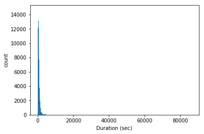

```python
bins = np.arange(50, 86114+5, 50)
plt.hist(data = bike_sub1, x = 'duration_sec', bins = bins);
plt.xlabel('Duration (sec)')
plt.ylabel('count');
# as expected, the result shows that it's highly skewed (more entries on the left side - shorter duration)
```

```python
# to fix the long tail in the distribution, let's put it on a log scale instead
np.log10(bike_sub1['duration_sec'].describe())
```

```
count    5.349546
mean     2.884526
std      3.247314
min      1.785330
25%      2.539076
50%      2.742725
75%      2.936514
max      4.935074
Name: duration_sec, dtype: float64
```

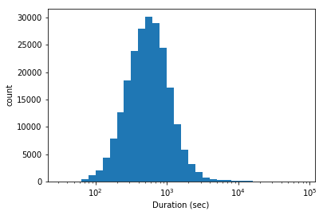

```python
bins_d = 10** np.arange(1.5, 4.93+0.01, 0.1)
plt.hist(data = bike_sub1, x = 'duration_sec', bins = bins_d);
plt.xscale('log');
plt.xlabel('Duration (sec)')
plt.ylabel('count');
# the shahpe overall improved, but it still shows that there are outliers with the max. time people kept the bike nearly 24hrs.
# remember, the max.time included in their pass for a customer is 30 min, and for a member is 45 min
```

> Log transformation made the histogram looks more like a bell shape, but we can still see that it has high outliers (e.g. the maximum time people kept a bike was nearly 24 hours). Considering the fact that normally a bike pass includes 30 minutes (for a customer) or 45 minutes (for a member) of ride time, 24 hour is way out of the normal pattern, although you can ride longer by paying \$3 for each additional 15 minutes. Moreover, descriptive statistics show that upper quartile is 864 seconds (14.4 min), which is way below the allowed ride time limit.  
> In order to determine the range of high outliers, let's first check how many actually kept a bike for more than 1 hour (3600 sec)

```python
# investigate the nubmer of users who kept the bike for longer than 1 hour (3600 sec)
over_1hr = sum(bike_sub1['duration_sec'] > 3600)
total_count = bike_sub1.shape[0]
print(over_1hr/total_count)
# the result (0.00898..) shows that it's less than 1% of users who kept a bike for more than 1 hour
```

```
0.008987739114104044
```

```python
# investigate the number of users who kept the bike for longer than 45 mintues (subscriber limit: 2700 sec)
over_45m = sum(bike_sub1['duration_sec'] > 2700)
print(over_45m/total_count)
# the result(0.01586..) still shows that users who kept a bike for more than 45 minutes count for only 1.6% of total users.
# Therefore, we can perhaps deal with data that contain the duration_sec value less than and equal to 45 mintues only
# 98.4% of total sample
```

```
0.01586492456559261
```

```python
# Select high outliers (duration_sec greater than 2700)
high_outliers = ((bike_sub1['duration_sec'] > 2700))
# Remove those and create a new subset
bike_sub2 = bike_sub1.loc[-high_outliers,:]
```

```python
# investigate the new subset
bike_sub2.duration_sec.describe()
```

```
count    220090.000000
mean        654.018661
std         434.660893
min          61.000000
25%         343.000000
50%         546.000000
75%         843.000000
max        2700.000000
Name: duration_sec, dtype: float64
```

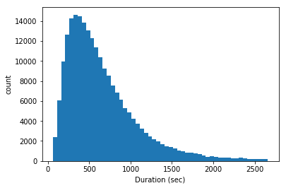

```python
# re-plot the distribution of duration_sec
bins = np.arange(60, 2700+5, 50)
plt.hist(data = bike_sub2, x = 'duration_sec', bins = bins);
plt.xlabel('Duration (sec)')
plt.ylabel('count');
```

```python
# log transform
np.log10(bike_sub2['duration_sec'].describe())
```

```
count    5.342600
mean     2.815590
std      2.638151
min      1.785330
25%      2.535294
50%      2.737193
75%      2.925828
max      3.431364
Name: duration_sec, dtype: float64
```

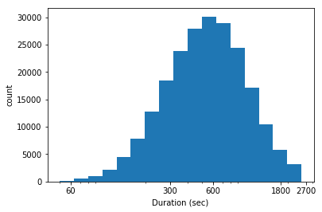

```python
# re-plot based on log transform
bins_d = 10** np.arange(1.7, 3.4+0.01, 0.1)
plt.hist(data = bike_sub2, x = 'duration_sec', bins = bins_d);
plt.xscale('log');
plt.xlabel('Duration (sec)')
plt.ylabel('count');
ticks = [60, 300, 600, 1800, 2700]
labels = ['{}'.format(v) for v in ticks]
plt.xticks(ticks, labels);
```

> The result shows that many of GoBike users used the service for around 600 seconds (10 minutes). The statistics reveal that the average duration they have used the service was 654 seconds (10.9 mins), and median is 546 seconds (9.1 mins). Quartiles show that 50% of the total sample used the bike between 343 seconds and 843 seconds (5.7 mins and 14.05 mins respectively). Based on this finding, we can guess that the GoBike service is normally used for a short distance trip (although the travelling speed might influence the distance of the journey for the same duration).

### 2. User type: whether they are a 'subscriber' who is a member of the scheme, or a 'customer' who uses a service on a causal basis

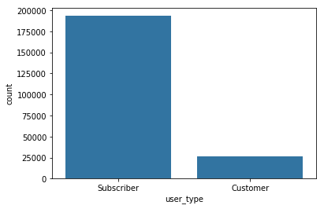

```python
# Categorical data, only two types: use a bar chart
base_color = sb.color_palette()[0]
sb.countplot(data = bike_sub2, x = 'user_type', color = base_color);
```

```python
# to show the percentage of the subscriber group
n_user = bike_sub2.shape[0]
user_count = bike_sub2['user_type'].value_counts()
max_user = user_count[0]
max_user_prop = max_user / n_user
print(max_user_prop)
```

```
0.8783997455586351
```

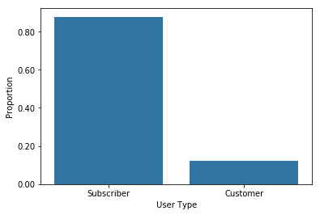

```python
# Plot the proportion
tick_props = np.arange(0, max_user_prop, 0.2)
tick_name = ['{:0.2f}'.format(v) for v in tick_props]

sb.countplot(data = bike_sub2, x = 'user_type', color = base_color);
plt.yticks(tick_props * n_user, tick_name)
plt.ylabel('Proportion');
plt.xlabel('User Type');
```

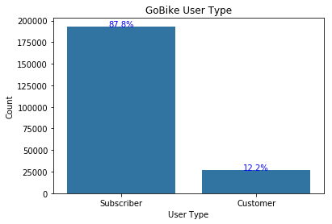

```python
# create the plot that shows both abosolute and relative frequency
base_color = sb.color_palette()[0]
sb.countplot(data = bike_sub2, x = 'user_type', color = base_color)
plt.ylabel('Count');
plt.xlabel('User Type');
plt.title('GoBike User Type')

# add annotations
n_points = bike_sub2.shape[0]
user_counts = bike_sub2['user_type'].value_counts()
locs, labels = plt.xticks() # get the current tick locations and labels

# loop through each pair of locations and labels
for loc, label in zip(locs, labels):

    # get the text property for the label to get the correct count
    count = user_counts[label.get_text()]
    pct_string = '{:0.1f}%'.format(100*count/n_points)

    # print the annotation just below the top of the bar
    plt.text(loc, count-4, pct_string, ha = 'center', color = 'b');
```

> The bar chart shows that 87.8% of users are a member (subscriber) of Ford GoBike, indicating that the main users of the system are more likely local residents, rather than visitors or tourists, who count for 12.2% of total users.

### 3. Gender: gender of GoBike users

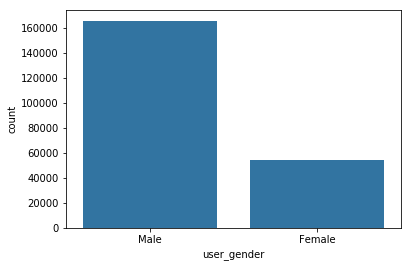

```python
# Categorical data, only two types: use a bar chart
base_color = sb.color_palette()[0]
sb.countplot(data = bike_sub2, x = 'user_gender', color = base_color);
```

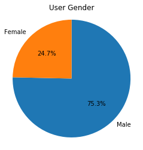

```python
# Create a pie chart for a change
sorted_counts = bike_sub2['user_gender'].value_counts()
plt.pie(sorted_counts, labels = sorted_counts.index, startangle = 90, counterclock = False, autopct = '%1.1f%%')
plt.axis('square');
plt.title('User Gender');
```

> From our early investigation, we know that this variable shows gender of both members and customers, not only 'member gender'. Based on this, the result shows that the majority of GoBike users are male. We can investigate further whether the high proportion of male is coming from a suscriber or a customer group later in Bivariate Exploration. So far there is no extra information that indicates why there is a higher number of male users compared to female, but this can be explored further later.

### 3. Retuern journey: whether a user returned to the start point or a different point

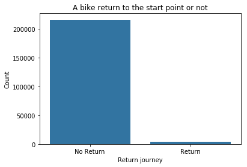

```python
# categorical data: a bar chart
base_color = sb.color_palette()[0]
sb.countplot(data = bike_sub2, x = 'return_j', color = base_color);
plt.ylabel('Count');
plt.xlabel('Return journey');
plt.title('A bike return to the start point or not');
```

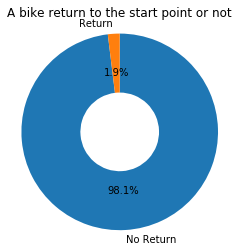

```python
# Create a donut plot for a change
sorted_counts = bike_sub2['return_j'].value_counts()
plt.pie(sorted_counts, labels = sorted_counts.index, startangle = 90, counterclock = False, autopct = '%1.1f%%', wedgeprops = {'width' : 0.6})
plt.axis('square');
plt.title('A bike return to the start point or not');
```

> The result shows that 98.1% bikes are not returned to the start point. It indicates that a bike is most likely used to travel from one point to another. This can have a close relationship with the user type and duration. We will investigate this relationship later in the Bivariate Exploration section.

### Discuss the distribution(s) of your variable(s) of interest. Were there any unusual points? Did you need to perform any transformations?

> The duration variable took on a large range of values, so I explored the data using a log transform. Under the transformation, the data looked unimodal, with one peak around 600 seconds (10 minutes) with a long tail on the right hand side. Those high outliers were removed and a new data subset was created. Findings from the user type and gender show that a majority of GoBike users are subscribers and male. Moreover, most bikes are not returned to the same start point, but to a different end point.

### Of the features you investigated, were there any unusual distributions? Did you perform any operations on the data to tidy, adjust, or change the form of the data? If so, why did you do this?

> Some of variables contain duplicating information (e.g. station_id, station_name, station_latitude, station_longitude: which all shows a unique location of a station). Instead, I used those location information of the station to create a new variable, called 'return_j', indicating whether a bike returned to the start point or not. Moreover, some variables are stored in a wrong dataformat (e.g. time, and birth year). Therefore, I have removed variables that are not relevant to the data analysis and created a subset. When investigating the gender variable, I found that there is another criteria called 'Other'. There was no extra information available to explain what this 'Other' meant, and therefore, those rows with 'member_gender = other' have been removed, along with 'NaN' rows. Moreover, the variable name 'member_gender' is misleading as it contains the gender information from both subscriber and customer groups.

## Bivariate Exploration

> As there are only one numerica variable (duration_sec) and three categorical variables (user_type, member_gender, and return_j), I first checked the relationship between trip duration and all three categorical variables. After this, relathipships among three categorical variables are explored.

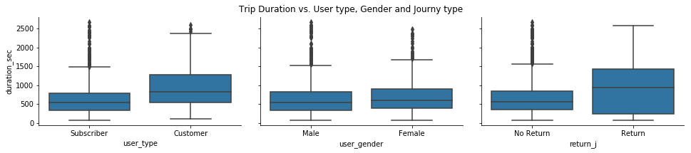

```python
# Trip duration vs. categorical variables
categoric_vars = ['user_type', 'user_gender', 'return_j']
samples = np.random.choice(bike_sub2.shape[0], 2000, replace = False)
bike_samp = bike_sub2.loc[samples,:]

def boxgrid(x, y, **kwargs):
    """ Quick hack for creating box plots with seaborn's PairGrid. """
    base_color = sb.color_palette()[0]
    sb.boxplot(x, y, color = base_color)

plt.figure(figsize = [10, 10])
g = sb.PairGrid(data = bike_samp, y_vars = ['duration_sec'], x_vars = categoric_vars,
                size = 3, aspect = 1.5)
plt.subplots_adjust(top=0.9)
g.fig.suptitle('Trip Duration vs. User type, Gender and Journy type')
g.map(boxgrid)
plt.show();
# the figures shows some interesting insights, but let's create another matrice for logarithm of duration
```

```python
# plot the categorical variables against duration again, this time with full data and variable transforms
# first compute the logarithm of duration to make multivariate plotting easier
def log_trans(x, inverse = False):
    """ quick function for computing log and power operations """
    if not inverse:
        return np.log10(x)
    else:
        return np.power(10, x)

bike_sub2['log_duration'] = bike_sub2['duration_sec'].apply(log_trans)
```

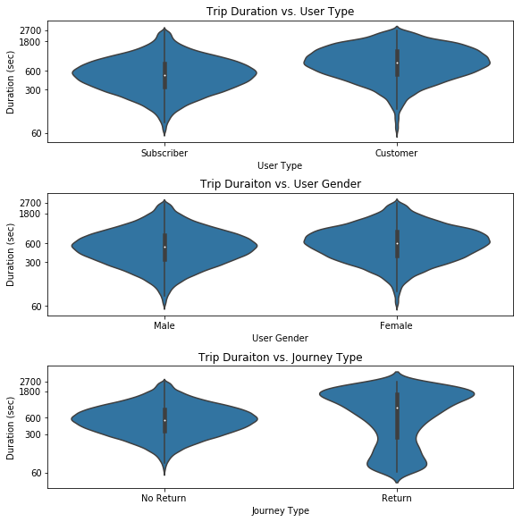

```python
# plot the categorical variables against duration again, this time with full data and variable transforms
fig, ax = plt.subplots(ncols = 1, nrows = 3 , figsize = [8,8],  constrained_layout=True)

for i in range(len(categoric_vars)):
    var = categoric_vars[i]
    sb.violinplot(data = bike_sub2, x = var, y = 'log_duration', ax = ax[i],
               color = base_color)
    ax[i].set_yticks(log_trans(np.array([60, 300, 600, 1800, 2700])))
    ax[i].set_yticklabels(['60', '300', '600', '1800', '2700'])
    ax[i].set_ylabel('Duration (sec)')

ax[0].set_title('Trip Duration vs. User Type');
ax[0].set_xlabel('User Type')
ax[1].set_title('Trip Duraiton vs. User Gender');
ax[1].set_xlabel('User Gender')
ax[2].set_title('Trip Duraiton vs. Journey Type');
ax[2].set_xlabel('Journey Type');

plt.show()
```

> The result shows that customers tend to use a bike for longer duration than subscribers and a bike that was used for a return journey was kept longer than a bike that returned to a different end point. However, despite the disproportionate gender distribution, there is not much difference between male and female in terms of the time they used a bike.

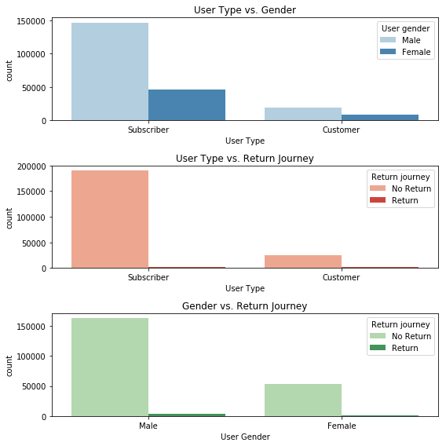

```python
# Let's investigate the relationship between categorical variables
plt.figure(figsize = [8, 8])

# subplot 1: user_type vs gender
plt.subplot(3, 1, 1)
sb.countplot(data = bike_sub2, x = 'user_type', hue = 'user_gender', palette = 'Blues')
plt.title('User Type vs. Gender')
plt.xlabel('User Type')
plt.legend(title = 'User gender')

# subplot 2: user_type vs. return_j
ax = plt.subplot(3, 1, 2)
sb.countplot(data = bike_sub2, x = 'user_type', hue = 'return_j', palette = 'Reds')
plt.title('User Type vs. Return Journey')
plt.xlabel('User Type')
plt.legend(title = 'Return journey');

# subplot 3: gender vs. return_j
ax = plt.subplot(3, 1, 3)
sb.countplot(data = bike_sub2, x = 'user_gender', hue = 'return_j', palette = 'Greens')
plt.title('Gender vs. Return Journey')
plt.xlabel('User Gender')
plt.legend(title = 'Return journey');

plt.tight_layout()
plt.show()
```

> The result shows that there are almost three times more male subcribers than female subscribers, and a large amount of subscribers do not return a bike to the same point (perhaps used for a commute purpose or part of their regular trips?). It also shows that compared to female, male users tend not to return a bike to the same station, but then this could be biased as there are more male users than female users. It would be good to divide the dataset based on subscribers and customers and do extra exploration later.

### Talk about some of the relationships you observed in this part of the investigation. How did the feature(s) of interest vary with other features in the dataset?

> Investigating the relationship between duration and other categorical variables was challenging due to the high outliers (even after removing some of extreme values during the cleaning process). Therefore, a log transformation of the duration variable is used to check the relationships with categorical variables, which show some interesting insights. It shows that customers in general used a bike for a longer time than subscribers, and when a bike is returned to the same station where they started, the duration was longer than when it was returned to a different station. However, although the previous investigation of gender revealed that there is a significantly higher number of male users, in terms of duration, there was no much difference between male and female users.

### Did you observe any interesting relationships between the other features (not the main feature(s) of interest)?

> Investigation of categorical variables show that it might be worth dividing the dataset based on the user type to show a pattern per group. This will be explored in the Multivariate Exploration section.

## Multivariate Exploration

> First we will separate the dataset into two based on the user type: Subscribers and Customers.

```python
user_sub = bike_sub2.query('user_type == "Subscriber"')
user_cus = bike_sub2.query('user_type == "Customer"')
```

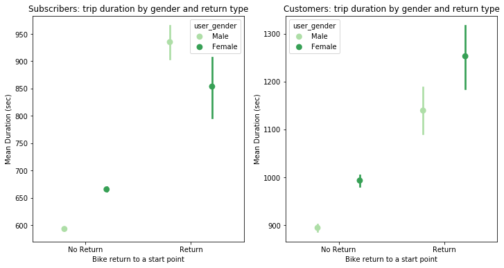

```python
# Gender vs. duration based on the user type  (no transformation)
fig, ax = plt.subplots(ncols = 2, figsize = [12,6])

sb.pointplot(data = user_sub, x = 'return_j', y = 'duration_sec', hue = 'user_gender',
             palette = 'Greens', linestyles = '', dodge = 0.4, ax = ax[0])
ax[0].set_title('Subscribers: trip duration by gender and return type')
ax[0].set_ylabel('Mean Duration (sec)')
ax[0].set_xlabel('Bike return to a start point')


sb.pointplot(data = user_cus, x = 'return_j', y = 'duration_sec', hue = 'user_gender',
             palette = 'Greens', linestyles = '', dodge = 0.4, ax = ax[1])
ax[1].set_title('Customers: trip duration by gender and return type')
ax[1].set_ylabel('Mean Duration (sec)')
ax[1].set_xlabel('Bike return to a start point')

plt.show();
```

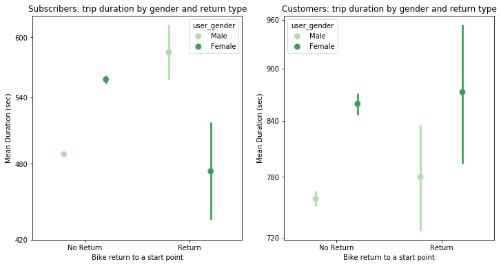

```python
# Gender vs. duration based on the user type (log_duration)
fig, ax = plt.subplots(ncols = 2, figsize = [12,6])

sb.pointplot(data = user_sub, x = 'return_j', y = 'log_duration', hue = 'user_gender',
             palette = 'Greens', linestyles = '', dodge = 0.4, ax = ax[0])
ax[0].set_title('Subscribers: trip duration by gender and return type')
ax[0].set_ylabel('Mean Duration (sec)')
ax[0].set_xlabel('Bike return to a start point')
ax[0].set_yticks(log_trans(np.array([420, 480, 540, 600])))
ax[0].set_yticklabels(['420', '480', '540', '600'])


sb.pointplot(data = user_cus, x = 'return_j', y = 'log_duration', hue = 'user_gender',
             palette = 'Greens', linestyles = '', dodge = 0.4, ax = ax[1])
ax[1].set_title('Customers: trip duration by gender and return type')
ax[1].set_ylabel('Mean Duration (sec)')
ax[1].set_xlabel('Bike return to a start point')
ax[1].set_yticks(log_trans(np.array([720, 780, 840, 900, 960])))
ax[1].set_yticklabels(['720', '780', '840', '900', '960'])

plt.show();
```

> The result shows that subscribers in general used a bike for a shorter period than customers, and interestingly for a bike that does not return to the start point (i.e. no return journey), female users (both subscribers and customers) rode a bike longer than male users (either they travelled longer distance or they cycled slower than male users). However, for a bike that returned to the start point (i.e. return journey), male subscribers used a bike for longer duration than female subscribers, but for customers, it was opposite. Female customers used a bike for a longer period than male customers, although there is a higher number of male customers. This is interesting - let's investigate further

```python
# Create two subset based on return_j
return_bike = bike_sub2.query('return_j  == "Return"')
no_return_bike = bike_sub2.query('return_j  == "No Return"')
```

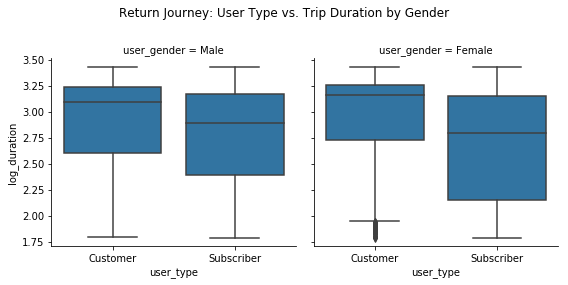

```python
# Return journey (bike return to the start point )
g = sb.FacetGrid(data = return_bike, col = 'user_gender', size = 4)
g.map(sb.boxplot, 'user_type', 'log_duration')

plt.subplots_adjust(top=0.8)
g.fig.suptitle('Return Journey: User Type vs. Trip Duration by Gender');
```

> For people who used the system for the return journey, customers rode a bike longer than subscribers (perhaps it's becuase subscribers have more options to travel with their membership, they use it to cover a different range of distances, while a customer paid per journey, they might have used it to maximise the value they paid for). In terms of gender, among customers female kept the bike longer than male, but for subscribers male used it for longer than female. It almost seems that female subscribers use the system to cover a shorter commute distance, while female customers either cycled for a longer distance or took an extra time to tour around. Without any other back-up information it is difficult to know what exactly caused such pattern.

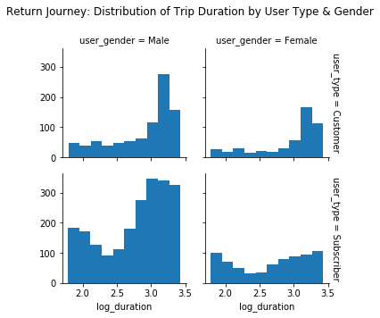

```python
# Return journey
g = sb.FacetGrid(data = return_bike, col = 'user_gender', row = 'user_type', size = 2.5,
                margin_titles = True)
g.map(plt.hist, 'log_duration')

plt.subplots_adjust(top=0.85)
g.fig.suptitle('Return Journey: Distribution of Trip Duration by User Type & Gender');
```

> The detailed distribution of duration shows that customers tend to use the system until the maximum allowance (probably to maximise the value they paid for), while subscribers used it cover either very short distance or long distance up to the limit (perhaps it's because they have flexibility to do so with their unlimited pass). The distribution shows an overall large number of male users as seen in the figure below (male users roughly 2.5 times more than female users among those who returned the bike to the start point)

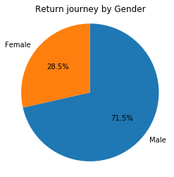

```python
# Return journey
sorted_counts = return_bike['user_gender'].value_counts()
plt.pie(sorted_counts, labels = sorted_counts.index, startangle = 90, counterclock = False, autopct = '%1.1f%%')
plt.axis('square');
plt.title('Return journey by Gender');
# roughly male 2.5 times more than female
```

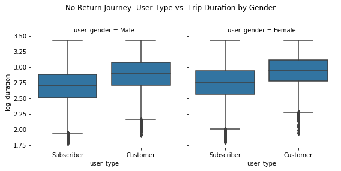

```python
# No Return journey (bike did not return to the start point )
g = sb.FacetGrid(data = no_return_bike, col = 'user_gender', size = 4)
g.map(sb.boxplot, 'user_type', 'log_duration')

plt.subplots_adjust(top=0.8)
g.fig.suptitle('No Return Journey: User Type vs. Trip Duration by Gender');
```

> For people who used the system for no return journey (e.g. transport from one poin to another), again customers rode a bike longer than subscribers. In terms of gender, female users tend to ride a bike for longer duration than male users - perhaps because male users cycled faster or female users travelled a longer distance. Again, without any other back-up information it is difficult to know what exactly caused such pattern.

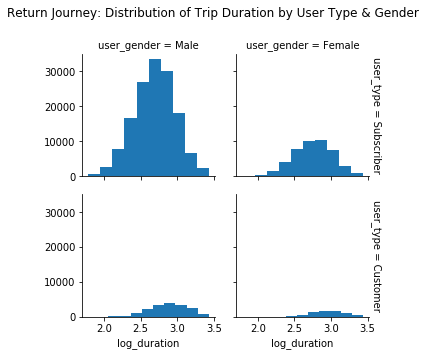

```python
# No Return journey
g = sb.FacetGrid(data = no_return_bike, col = 'user_gender', row = 'user_type', size = 2.5,
                margin_titles = True)
g.map(plt.hist, 'log_duration')

plt.subplots_adjust(top=0.85)
g.fig.suptitle('Return Journey: Distribution of Trip Duration by User Type & Gender');
```

> The detailed distribution of duration shows that interestingly relatively low customers used the service to transport to one point to another, while subscribers tend to use it more and the pattern looks normal distributed. Again, the position of the mode shows that customers used the system to cover longer duration than subscribers. The gender difference is perhaps due to the number difference as seen in the figure below (the number of male users 3 times higher than female number).

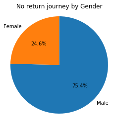

```python
sorted_counts = no_return_bike['user_gender'].value_counts()
plt.pie(sorted_counts, labels = sorted_counts.index, startangle = 90, counterclock = False, autopct = '%1.1f%%')
plt.axis('square');
plt.title('No return journey by Gender');
# roughly male 3 times more than female
```

### Talk about some of the relationships you observed in this part of the investigation. Were there features that strengthened each other in terms of looking at your feature(s) of interest?

> It explains more about how people might use the GoBike service depending on the user type. For example, from the bivariate explaraton, the majority of users are identified as male and subscribers, and they tend to use the service to travel from one point to another with average ride time of 10 mintues. However, the multivariate exploration shows that customers (targetted for visitors and tourists) tend to keep the bike longer than subscribers (e.g. local residents) although a member pass allows longer ride time (45 minutes) than a casual pass (30 minutes). Moreover, the distribution of duration show that for a bike that returned to the start point, subscribers have two high points for the low duration and high duration, while customers have one high point towards the longer duration. This is perhaps caused by the fact that a subscriber has unlimited 45-minute rides where they could use it as many times as possible as long as it's under 45 mintues, while for customers they paid for a limited use of a bike, and therefore, they tend to use it for a longer time (probably until the maximum limit, which is 30 minutes), rather than a short time.

### Were there any interesting or surprising interactions between features?

> Because the number of male users was significantly higher than the number of female users, I expected that the average duration of male would be higher than female's. However, the multivariate exploration shows the gender difference is most likely to be seen in a different user type (i.e. whether they are customers or subscribers), or in a journey type (i.e. whether a bike was used for the return journey or not).